# #Python Tutorial

```python
str1[6:12] # String slicing - Retreive all characters between 6 - 12 index loc excluding index loc 12.
```

```
'PYTHON'
```

```python
str1[-4:] # Retreive last four characters of the string
```

```
'THON'
```

```python
str1[-6:] # Retreive last six characters of the string
```

```
'PYTHON'
```

```python
str1[:6] # Retreive first six characters of the string
```

```
'HELLO '
```

Update & Delete String

```python
str1
```

```
'HELLO PYTHON'
```

```python
#Strings are immutable which means elements of a string cannot be changed once they have been assigned.
str1[0:5] = 'HOLAA'
```

```
---------------------------------------------------------------------------
TypeError                                 Traceback (most recent call last)
<ipython-input-78-5797fff88f23> in <module>
      1 #Strings are immutable which means elements of a string cannot be changed once they have been assigned.
----> 2 str1[0:5] = 'HOLAA'

TypeError: 'str' object does not support item assignment
```

```python
del str1 # Delete a string
print(srt1)
```

```
---------------------------------------------------------------------------
NameError                                 Traceback (most recent call last)
<ipython-input-79-7fcc0cc83dcc> in <module>
      1 del str1 # Delete a string
----> 2 print(srt1)

NameError: name 'srt1' is not defined
```

String concatenation

```python
# String concatenation
s1 = "Hello"
s2 = "Sonu"
s3 = s1 + s2
print(s3)
```

```
HelloSonu
```

```python
# String concatenation
s1 = "Hello"
s2 = "Sonu"
s3 = s1 + " " + s2
print(s3)
```

```
Hello Sonu
```

Iterating through a String

```python
mystr1 = "Hello Everyone"
```

```python
# Iteration
for i in mystr1:
    print(i)
```

```
H
e
l
l
o

E
v
e
r
y
o
n
e
```

```python
for i in enumerate(mystr1):
    print(i)
```

```
(0, 'H')
(1, 'e')
(2, 'l')
(3, 'l')
(4, 'o')
(5, ' ')
(6, 'E')
(7, 'v')
(8, 'e')
(9, 'r')
(10, 'y')
(11, 'o')
(12, 'n')
(13, 'e')
```

```python
list(enumerate(mystr1)) # Enumerate method adds a counter to an iterable and returns it in a form of enumerate object.
```

```
[(0, 'H'),
 (1, 'e'),
 (2, 'l'),
 (3, 'l'),
 (4, 'o'),
 (5, ' '),
 (6, 'E'),
 (7, 'v'),
 (8, 'e'),
 (9, 'r'),
 (10, 'y'),
 (11, 'o'),
 (12, 'n'),
 (13, 'e')]
```

String Membership

```python
# String membership
mystr1 = "Hello Everyone"
print ('Hello' in mystr1) # Check whether substring "Hello" is present in string "mysrt1"
print ('Everyone' in mystr1) # Check whether substring "Everyone" is present in string "mysrt1"
print ('Hi' in mystr1) # Check whether substring "Hi" is present in string "mysrt1"
```

```
True
True
False
```

String Partitioning

```python
"""
The partition() method searches for a specified string and splits the string into a tuple containing three elements.
- The first element contains the part before the argument string.
- The second element contains the argument string.
- The third element contains the part after the argument string.
"""
str5 = "Natural language processing with Python and R and Java"
L = str5.partition("and")
print(L)
```

```
('Natural language processing with Python ', 'and', ' R and Java')
```

```python
"""
The rpartition() method searches for the last occurence of the specified string and splits the string into a tuple
containing three elements.
- The first element contains the part before the argument string.
- The second element contains the argument string.
- The third element contains the part after the argument string.
"""
str5 = "Natural language processing with Python and R and Java"
L = str5.rpartition("and")
print(L)
```

```
('Natural language processing with Python and R ', 'and', ' Java')
```

String Functions

```python
mystr2 = " Hello Everyone  "
mystr2
```

```
' Hello Everyone  '
```

```python
mystr2.strip() # Removes white space from begining & end
```

```
'Hello Everyone'
```

```python
mystr2.lstrip() # Removes all whitespaces at the begining of the string
```

```
'Hello Everyone  '
```

```python
mystr2 = "*********Hello Everyone***********All the Best**********"
mystr2
```

```
'*********Hello Everyone***********All the Best**********'
```

```python
mystr2.strip('*') # Removes all '*' characters from begining & end of the string
```

```
'Hello Everyone***********All the Best'
```

```python
mystr2.rstrip('*') # Removes all '*' characters at the end of the string
```

```
'*********Hello Everyone***********All the Best'
```

```python
mystr2.lstrip('*') # Removes all '*' characters at the begining of the string
```

```
'Hello Everyone***********All the Best**********'
```

```python
mystr2 = "    Hello Everyone    "
```

```python
mystr2.lower() # Return whole string in lowercase
```

```
'    hello everyone    '
```

```python
mystr2.upper() # Return whole string in uppercase
```

```
'    HELLO EVERYONE    '
```

```python
mystr2.replace("He" , "Ho") #Replace substring "He" with "Ho"
```

```
'    Hollo Everyone    '
```

```python
mystr2.replace(" " , "") # Remove all whitespaces using replace function
```

```
'HelloEveryone'
```

```python
mystr5 = "one two Three one two two three"
```

```python
mystr5.count("one") # Number of times substring "one" occurred in string.
```

```
2
```

```python
mystr5.count("two") # Number of times substring "two" occurred in string.
```

```
3
```

```python
mystr5.startswith("one")
# Return boolean value True if string starts with "one"
```

```
True
```

```python
mystr5.endswith("three") # Return boolean value True if string ends with "three"
```

```
True
```

```python
mystr4 = "one two three four one two two three five five six seven six seven one one one ten eight ten nine eleven ten"
```

```python
mylist = mystr4.split() # Split String into substrings
mylist
```

```
['one',
 'two',
 'three',
 'four',
 'one',
 'two',
 'two',
 'three',
 'five',
 'five',
 'six',
 'seven',
 'six',
 'seven',
 'one',
 'one',
 'one',
 'ten',
 'eight',
 'ten',
 'nine',
 'eleven',
 'ten']
```

```python
# Combining string & numbers using format method
item1 = 40
item2 = 55
item3 = 77
res = "Cost of item1 , item2 and item3 are {} , {} and {}"
print(res.format(item1,item2,item3))
```

```
Cost of item1 , item2 and item3 are 40 , 55 and 77
```

```python
# Combining string & numbers using format method
item1 = 40
item2 = 55
item3 = 77
res = "Cost of item3 , item2 and item1 are {2} , {1} and {0}"
print(res.format(item1,item2,item3))
```

```
Cost of item3 , item2 and item1 are 77 , 55 and 40
```

```python
str2 = " WELCOME EVERYONE "
str2 = str2.center(100) # center align the string using a specific character as the fill character.
print(str2)
```

```
                                          WELCOME EVERYONE
```

```python
str2 = " WELCOME EVERYONE "
str2 = str2.center(100,'*') # center align the string using a specific character ('*') as the fill character.
print(str2)
```

```
***************************************** WELCOME EVERYONE *****************************************
```

```python
str2 = " WELCOME EVERYONE "
str2 = str2.rjust(50) # Right align the string using a specific character as the fill character.
print(str2)
```

```
                                 WELCOME EVERYONE
```

```python
str2 = " WELCOME EVERYONE "
str2 = str2.rjust(50,'*') # Right align the string using a specific character ('*') as the fill character.
print(str2)
```

```
******************************** WELCOME EVERYONE
```

```python
str4 = "one two three four five six seven"
loc = str4.find("five") # Find the location of word 'five' in the string "str4"
print(loc)
```

```
19
```

```python
str4 = "one two three four five six seven"
loc = str4.index("five") # Find the location of word 'five' in the string "str4"
print(loc)
```

```
19
```

```python
mystr6 = '123456789'
print(mystr6.isalpha()) # returns True if all the characters in the text are letters
print(mystr6.isalnum()) # returns True if a string contains only letters or numbers or both
print(mystr6.isdecimal()) # returns True if all the characters are decimals (0-9)
print(mystr6.isnumeric()) # returns True if all the characters are numeric (0-9)
```

```
False
True
True
True
```

```python
mystr6 = 'abcde'
print(mystr6.isalpha()) # returns True if all the characters in the text are letters
print(mystr6.isalnum()) # returns True if a string contains only letters or numbers or both
print(mystr6.isdecimal()) # returns True if all the characters are decimals (0-9)
print(mystr6.isnumeric()) # returns True if all the characters are numeric (0-9)
```

```
True
True
False
False
```

```python
mystr6 = 'abc12309'
print(mystr6.isalpha()) # returns True if all the characters in the text are letters
print(mystr6.isalnum()) # returns True if a string contains only letters or numbers or both
print(mystr6.isdecimal()) # returns True if all the characters are decimals (0-9)
print(mystr6.isnumeric()) # returns True if all the characters are numeric (0-9)
```

```
False
True
False
False
```

```python
mystr7 = 'ABCDEF'
print(mystr7.isupper())
print(mystr7.islower())
# Returns True if all the characters are in upper case
# Returns True if all the characters are in lower case
```

```
True
False
```

```python
mystr8 = 'abcdef'
print(mystr8.isupper())
print(mystr8.islower())
# Returns True if all the characters are in upper case
# Returns True if all the characters are in lower case
```

```
False
True
```

```python
str6 = "one two three four one two two three five five six one ten eight ten nine eleven ten ten nine"
loc = str6.rfind("one") # last occurrence of word 'one' in string "str6"
print(loc)
```

```
51
```

```python
loc = str6.rindex("one") # last occurrence of word 'one' in string "str6"
print(loc)
```

```
51
```

```python
txt = "      abc def ghi       "
txt.rstrip()
```

```
'      abc def ghi'
```

```python
txt = "  abc def ghi   "
txt.lstrip()
```

```
'abc def ghi   '
```

```python
txt = "  abc def ghi   "
txt.strip()
```

```
'abc def ghi'
```

Using Escape Character

```python
#Using double quotes in the string is not allowed.
mystr = "My favourite TV Series is "Game of Thrones""
```

```
  File "<ipython-input-130-0fa35a74da86>", line 2
    mystr = "My favourite TV Series is "Game of Thrones""
                                           ^
SyntaxError: invalid syntax
```

```python
#Using escape character to allow illegal characters
mystr = "My favourite series is \"Game of Thrones\""
print(mystr)
```

```
My favourite series is "Game of Thrones"
```

# List

1) List is an ordered sequence of items.

2) We can have different data types under a list. E.g we can have integer, float and string items in a same list.

# List Creation

```python
list1 = []
# Empty List
```

```python
print(type(list1))
```

```
<class 'list'>
```

```python
list2 = [10,30,60]
# List of integers numbers
```

```python
list3 = [10.77,30.66,60.89] # List of float numbers
```

```python
list4 = ['one','two' , "three"] # List of strings
```

```python
list5 = ['Sonu', 25 ,[50, 100],[150, 90]] # Nested Lists
```

```python
list6 = [100, 'Sonu', 17.765] # List of mixed data types
```

```python
list7 = ['Sonu', 25 ,[50, 100],[150, 90] , {'John' , 'David'}]
```

```python
len(list6) #Length of list
```

```
3
```

# List Indexing

```python
list2[0] # Retreive first element of the list
```

```
10
```

```python
list4[0] # Retreive first element of the list
```

```
'one'
```

```python
list4[0][0] # Nested indexing - Access the first character of the first list element
```

```
'o'
```

```python
list4[-1] # Last item of the list
```

```
'three'
```

```python
list5[-1]
# Last item of the list
```

```
[150, 90]
```

# List Slicing

```python
mylist = ['one' , 'two' , 'three' , 'four' , 'five' , 'six' , 'seven' , 'eight']
```

```python
mylist[0:3] # Return all items from 0th to 3rd index location excluding the item at loc 3.
```

```
['one', 'two', 'three']
```

```python
mylist[2:5] # List all items from 2nd to 5th index location excluding the item at loc 5.
```

```
['three', 'four', 'five']
```

```python
mylist[:3] # Return first three items
```

```
['one', 'two', 'three']
```

```python
mylist[:2]
# Return first two items
```

```
['one', 'two']
```

```python
mylist[-3:] # Return last three items
```

```
['six', 'seven', 'eight']
```

```python
mylist[-2:] # Return last two items
```

```
['seven', 'eight']
```

```python
mylist[-1] # Return last item of the list
```

```
'eight'
```

```python
mylist[:] # Return whole list
```

```
['one', 'two', 'three', 'four', 'five', 'six', 'seven', 'eight']
```

# Add , Remove & Change Items

```python
mylist
```

```
['one', 'two', 'three', 'four', 'five', 'six', 'seven', 'eight']
```

```python
mylist.append('nine') # Add an item to the end of the list
mylist
```

```
['one', 'two', 'three', 'four', 'five', 'six', 'seven', 'eight', 'nine']
```

```python
mylist.insert(9,'ten') # Add item at index location 9
mylist
```

```
['one', 'two', 'three', 'four', 'five', 'six', 'seven', 'eight', 'nine', 'ten']
```

```python
mylist.insert(1,'ONE') # Add item at index location 1
mylist
```

```
['one',
 'ONE',
 'two',
 'three',
 'four',
 'five',
 'six',
 'seven',
 'eight',
 'nine',
 'ten']
```

```python
mylist.remove('ONE') # Remove item "ONE"
mylist
```

```
['one', 'two', 'three', 'four', 'five', 'six', 'seven', 'eight', 'nine', 'ten']
```

```python
mylist.pop() # Remove last item of the list
mylist
```

```
['one', 'two', 'three', 'four', 'five', 'six', 'seven', 'eight', 'nine']
```

```python
mylist.pop(8) # Remove item at index location 8
mylist
```

```
['one', 'two', 'three', 'four', 'five', 'six', 'seven', 'eight']
```

```python
del mylist[7] # Remove item at index location 7
mylist
```

```
['one', 'two', 'three', 'four', 'five', 'six', 'seven']
```

```python
# Change value of the string
mylist[0] = 1
mylist[1] = 2
mylist[2] = 3
mylist
```

```
[1, 2, 3, 'four', 'five', 'six', 'seven']
```

```python
mylist.clear()
mylist
# Empty List / Delete all items in the list
```

```
[]
```

```python
del mylist # Delete the whole list
mylist
```

```
---------------------------------------------------------------------------
NameError                                 Traceback (most recent call last)
<ipython-input-167-50c7849aa2cb> in <module>
      1 del mylist # Delete the whole list
----> 2 mylist

NameError: name 'mylist' is not defined
```

# Copy List

```python
mylist = ['one', 'two', 'three', 'four', 'five', 'six', 'seven', 'eight', 'nine', 'ten']
```

```python
mylist1 = mylist # Create a new reference "mylist1"
```

```python
id(mylist) , id(mylist1) # The address of both mylist & mylist1 will be the same as both are pointing to same list.
```

```
(140147616757384, 140147616757384)
```

```python
mylist2 = mylist.copy() # Create a copy of the list
```

```python
id(mylist2) # The address of mylist2 will be different from mylist because mylist2 is pointing to the copy of the existin
```

```
140147257361992
```

```python
mylist[0] = 1
```

```python
mylist
```

```
[1, 'two', 'three', 'four', 'five', 'six', 'seven', 'eight', 'nine', 'ten']
```

```python
mylist1 # mylist1 will be also impacted as it is pointing to the same list
```

```
[1, 'two', 'three', 'four', 'five', 'six', 'seven', 'eight', 'nine', 'ten']
```

```python
mylist2 # Copy of list won't be impacted due to changes made on the original list
```

```
['one', 'two', 'three', 'four', 'five', 'six', 'seven', 'eight', 'nine', 'ten']
```

# Join Lists

```python
list1 = ['one', 'two', 'three', 'four']
list2 = ['five', 'six', 'seven', 'eight']
```

```python
list3 = list1 + list2 # Join two lists by '+' operator
list3
```

```
['one', 'two', 'three', 'four', 'five', 'six', 'seven', 'eight']
```

```python
list1.extend(list2) #Append list2 with list1
list1
```

```
['one', 'two', 'three', 'four', 'five', 'six', 'seven', 'eight']
```

# List Membership

```python
list1
```

```
['one', 'two', 'three', 'four', 'five', 'six', 'seven', 'eight']
```

```python
'one' in list1 # Check if 'one' exist in the list
```

```
True
```

```python
'ten' in list1 # Check if 'ten' exist in the list
```

```
False
```

```python
if 'three' in list1: # Check if 'three' exist in the list
    print('Three is present in the list')
else:
    print('Three is not present in the list')
```

```
Three is present in the list
```

```python
if 'eleven' in list1: # Check if 'eleven' exist in the list
    print('eleven is present in the list')
else:
    print('eleven is not present in the list')
```

```
eleven is not present in the list
```

# Reverse & Sort List

```python
list1
```

```
['one', 'two', 'three', 'four', 'five', 'six', 'seven', 'eight']
```

```python
list1.reverse() # Reverse the list
list1
```

```
['eight', 'seven', 'six', 'five', 'four', 'three', 'two', 'one']
```

```python
list1 = list1[::-1] # Reverse the list
list1
```

```
['one', 'two', 'three', 'four', 'five', 'six', 'seven', 'eight']
```

```python
mylist3 = [9,5,2,99,12,88,34]
mylist3.sort()
# Sort list in ascending order
mylist3
```

```
[2, 5, 9, 12, 34, 88, 99]
```

```python
mylist3 = [9,5,2,99,12,88,34]
mylist3.sort(reverse=True) # Sort list in descending order
mylist3
```

```
[99, 88, 34, 12, 9, 5, 2]
```

```python
mylist4 = [88,65,33,21,11,98]
sorted(mylist4)
# Returns a new sorted list and doesn't change original list
```

```
[11, 21, 33, 65, 88, 98]
```

```python
mylist4
```

```
[88, 65, 33, 21, 11, 98]
```

# Loop through a list

```python
list1
```

```
['one', 'two', 'three', 'four', 'five', 'six', 'seven', 'eight']
```

```python
for i in list1:
    print(i)
```

```
one
two
three
four
five
six
seven
eight
```

```python
for i in enumerate(list1):
    print(i)
```

```
(0, 'one')
(1, 'two')
(2, 'three')
(3, 'four')
(4, 'five')
(5, 'six')
(6, 'seven')
(7, 'eight')
```

# Count

```python
list10 =['one', 'two', 'three', 'four', 'one', 'one', 'two', 'three']
```

```python
list10.count('one') # Number of times item "one" occurred in the list.
```

```
3
```

```python
list10.count('two') # Occurence of item 'two' in the list
```

```
2
```

```python
list10.count('four') #Occurence of item 'four' in the list
```

```
1
```

# All / Any The all() method returns: True - If all elements in a list are true False - If any element in a list is false The any() function returns True if any element in the list is True. If not, any() returns False.

```python
L1 = [1,2,3,4,0]
```

```python
all(L1) # Will Return false as one value is false (Value 0)
```

```
False
```

```python
any(L1)
# Will Return True as we have items in the list with True value
```

```
True
```

```python
L2 = [1,2,3,4,True,False]
```

```python
all(L2) # Returns false as one value is false
```

```
False
```

```python
any(L2)
# Will Return True as we have items in the list with True value
```

```
True
```

```python
L3 = [1,2,3,True]
```

```python
all(L3) # Will return True as all items in the list are True
```

```
True
```

# List Comprehensions List Comprehensions provide an elegant way to create new lists. It consists of brackets containing an expression followed by a for clause, then zero or more for or if clauses.

```python
mystring = "WELCOME"
mylist = [ i for i in mystring ] # Iterating through a string Using List Comprehension
mylist
```

```
['W', 'E', 'L', 'C', 'O', 'M', 'E']
```

```python
mylist1 = [ i for i in range(40) if i % 2 == 0] # Display all even numbers between 0 - 40 using List Comprehension
mylist1
```

```
[0, 2, 4, 6, 8, 10, 12, 14, 16, 18, 20, 22, 24, 26, 28, 30, 32, 34, 36, 38]
```

```python
mylist2 = [ i for i in range(40) if i % 2 == 1] # Display all odd numbers between 0 - 40 using List Comprehension
mylist2
```

```
[1, 3, 5, 7, 9, 11, 13, 15, 17, 19, 21, 23, 25, 27, 29, 31, 33, 35, 37, 39]
```

```python
mylist3 = [num**2 for num in range(10)] # calculate square of all numbers between 0 - 10 using List Comprehension
mylist3
```

```
[0, 1, 4, 9, 16, 25, 36, 49, 64, 81]
```

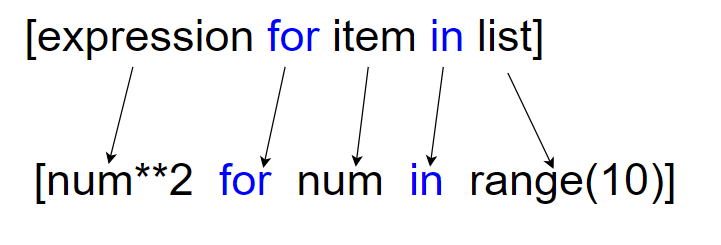

```python
# Multiple whole list by 10
list1 = [2,3,4,5,6,7,8]
list1 = [i*10 for i in list1]
list1
```

```
[20, 30, 40, 50, 60, 70, 80]
```

```python
#List all numbers divisible by 3 , 9 & 12 using nested "if" with List Comprehension
mylist4 = [i for i in range(200) if i % 3 == 0 if i % 9 == 0 if i % 12 == 0]
mylist4
```

```
[0, 36, 72, 108, 144, 180]
```

```python
# Odd even test
l1 = [print("{} is Even Number".format(i)) if i%2==0 else print("{} is odd number".format(i)) for i in range(10)]
```

```
0 is Even Number
1 is odd number
2 is Even Number
3 is odd number
4 is Even Number
5 is odd number
6 is Even Number
7 is odd number
8 is Even Number
9 is odd number
```

```python
# Extract numbers from a string
mystr = "One 1 two 2 three 3 four 4 five 5 six 6789"
numbers = [i for i in mystr if i.isdigit()]
numbers
```

```
['1', '2', '3', '4', '5', '6', '7', '8', '9']
```

```python
# Extract letters from a string
mystr = "One 1 two 2 three 3 four 4 five 5 six 6789"
numbers = [i for i in mystr if i.isalpha()]
numbers
```

```
['O',
 'n',
 'e',
 't',
 'w',
 'o',
 't',
 'h',
 'r',
 'e',
 'e',
 'f',
 'o',
 'u',
 'r',
 'f',
 'i',
 'v',
 'e',
 's',
 'i',
 'x']
```

# Tuples

1. Tuple is similar to List except that the objects in tuple are immutable which means we cannot change the elements of a tuple once assigned.
2. When we do not want to change the data over time, tuple is a preferred data type.
3. Iterating over the elements of a tuple is faster compared to iterating over a list.

# Tuple Creation

```python
tup1 = ()
# Empty tuple
```

```python
tup2 = (10,30,60)
# tuple of integers numbers
```

```python
tup3 = (10.77,30.66,60.89) # tuple of float numbers
```

```python
tup4 = ('one','two' , "three") # tuple of strings
```

```python
tup5 = ('Asif', 25 ,(50, 100),(150, 90))  # Nested tuples
```

```python
tup6 = (100, 'Sonu', 17.765) # Tuple of mixed data types
```

```python
tup7 = ('Sonu', 25 ,[50, 100],[150, 90] , {'John' , 'David'} , (99,22,33))
```

```python
len(tup7) #Length of list
```

```
6
```

# Tuple Indexing

```python
tup2[0] # Retreive first element of the tuple
```

```
10
```

```python
tup4[0] # Retreive first element of the tuple
```

```
'one'
```

```python
tup4[0][0] # Nested indexing - Access the first character of the first tuple element
```

```
'o'
```

```python
tup4[-1] # Last item of the tuple
```

```
'three'
```

```python
tup5[-1]
# Last item of the tuple
```

```
(150, 90)
```

# Tuple Slicing

```python
mytuple = ('one' , 'two' , 'three' , 'four' , 'five' , 'six' , 'seven' , 'eight')
```

```python
mytuple[0:3] # Return all items from 0th to 3rd index location excluding the item at loc 3.
```

```
('one', 'two', 'three')
```

```python
mytuple[2:5] # List all items from 2nd to 5th index location excluding the item at loc 5.
```

```
('three', 'four', 'five')
```

```python
mytuple[:3] # Return first three items
```

```
('one', 'two', 'three')
```

```python
mytuple[:2]
# Return first two items
```

```
('one', 'two')
```

```python
mytuple[-3:] # Return last three items
```

```
('six', 'seven', 'eight')
```

```python
mytuple[-2:] # Return last two items
```

```
('seven', 'eight')
```

```python
mytuple[-1] # Return last item of the tuple
```

```
'eight'
```

```python
mytuple[:] # Return whole tuple
```

```
('one', 'two', 'three', 'four', 'five', 'six', 'seven', 'eight')
```

# Remove & Change Items

```python
mytuple
```

```
('one', 'two', 'three', 'four', 'five', 'six', 'seven', 'eight')
```

```python
del mytuple[0] # Tuples are immutable which means we can't DELETE tuple items
```

```
---------------------------------------------------------------------------
TypeError                                 Traceback (most recent call last)
<ipython-input-240-96051e0b9682> in <module>
----> 1 del mytuple[0] # Tuples are immutable which means we can't DELETE tuple items

TypeError: 'tuple' object doesn't support item deletion
```

```python
mytuple[0] = 1 # Tuples are immutable which means we can't CHANGE tuple items
```

```
---------------------------------------------------------------------------
TypeError                                 Traceback (most recent call last)
<ipython-input-241-4c2ed09725a9> in <module>
----> 1 mytuple[0] = 1 # Tuples are immutable which means we can't CHANGE tuple items

TypeError: 'tuple' object does not support item assignment
```

```python
del mytuple # Deleting entire tuple object is possible
```

# Loop through a tuple

```python
mytuple = ('one' , 'two' , 'three' , 'four' , 'five' , 'six' , 'seven' , 'eight')
mytuple
```

```
('one', 'two', 'three', 'four', 'five', 'six', 'seven', 'eight')
```

```python
for i in mytuple:
    print(i)
```

```
one
two
three
four
five
six
seven
eight
```

```python
for i in enumerate(mytuple):
    print(i)
```

```
(0, 'one')
(1, 'two')
(2, 'three')
(3, 'four')
(4, 'five')
(5, 'six')
(6, 'seven')
(7, 'eight')
```

# Count

```python
mytuple1 =('one', 'two', 'three', 'four', 'one', 'one', 'two', 'three')
```

```python
mytuple1.count('one') # Number of times item "one" occurred in the tuple.
```

```
3
```

```python
mytuple1.count('two') # Occurence of item 'two' in the tuple
```

```
2
```

```python
mytuple1.count('four') #Occurence of item 'four' in the tuple
```

```
1
```

# Tuple Membership

```python
mytuple
```

```
('one', 'two', 'three', 'four', 'five', 'six', 'seven', 'eight')
```

```python
'one' in mytuple # Check if 'one' exist in the list
```

```
True
```

```python
'ten' in mytuple # Check if 'ten' exist in the list
```

```
False
```

```python
if 'three' in mytuple: # Check if 'three' exist in the list
    print('Three is present in the tuple')
else:
    print('Three is not present in the tuple')
```

```
Three is present in the tuple
```

```python
if 'eleven' in mytuple: # Check if 'eleven' exist in the list
    print('eleven is present in the tuple')
else:
    print('eleven is not present in the tuple')
```

```
eleven is not present in the tuple
```

# Index Position

```python
mytuple
```

```
('one', 'two', 'three', 'four', 'five', 'six', 'seven', 'eight')
```

```python
mytuple.index('one') # Index of first element equal to 'one'
```

```
0
```

```python
mytuple.index('five') # Index of first element equal to 'five'
```

```
4
```

```python
mytuple1
```

```
('one', 'two', 'three', 'four', 'one', 'one', 'two', 'three')
```

```python
mytuple1.index('one') # Index of first element equal to 'one'
```

```
0
```

# Sorting

```python
mytuple2 = (43,67,99,12,6,90,67)
```

```python
sorted(mytuple2)
# Returns a new sorted list and doesn't change original tuple
```

```
[6, 12, 43, 67, 67, 90, 99]
```

```python
sorted(mytuple2, reverse=True) # Sort in descending order
```

```
[99, 90, 67, 67, 43, 12, 6]
```

# Sets

1) Unordered & Unindexed collection of items.

2) Set elements are unique. Duplicate elements are not allowed.

3) Set elements are immutable (cannot be changed).

4) Set itself is mutable. We can add or remove items from it.

# Set Creation

```python
myset = {1,2,3,4,5} # Set of numbers
myset
```

```
{1, 2, 3, 4, 5}
```

```python
len(myset) #Length of the set
```

```
5
```

```python
my_set = {1,1,2,2,3,4,5,5}
my_set
# Duplicate elements are not allowed.
```

```
{1, 2, 3, 4, 5}
```

```python
myset1 = {1.79,2.08,3.99,4.56,5.45} # Set of float numbers
myset1
```

```
{1.79, 2.08, 3.99, 4.56, 5.45}
```

```python
myset2 = {'sonu' , 'John' , 'Tyrion'} # Set of Strings
myset2
```

```
{'John', 'Tyrion', 'sonu'}
```

```python
myset3 = {10,20, "Hola", (11, 22, 32)} # Mixed datatypes
myset3
```

```
{(11, 22, 32), 10, 20, 'Hola'}
```

```python
myset3 = {10,20, "Hola", [11, 22, 32]} # set doesn't allow mutable items like lists
myset3
```

```
---------------------------------------------------------------------------
TypeError                                 Traceback (most recent call last)
<ipython-input-31-d23fdc3a319e> in <module>
----> 1 myset3 = {10,20, "Hola", [11, 22, 32]} # set doesn't allow mutable items like lists
      2 myset3

TypeError: unhashable type: 'list'
```

```python
myset4 = set() # Create an empty set
print(type(myset4))
```

```
<class 'set'>
```

```python
my_set1 = set(('one' , 'two' , 'three' , 'four'))
my_set1
```

```
{'four', 'one', 'three', 'two'}
```

# Loop through a Set

```python
myset = {'one', 'two', 'three', 'four', 'five', 'six', 'seven', 'eight'}
for i in myset:
    print(i)
```

```
eight
one
six
seven
two
three
four
five
```

```python
for i in enumerate(myset):
    print(i)
```

```
(0, 'eight')
(1, 'one')
(2, 'six')
(3, 'seven')
(4, 'two')
(5, 'three')
(6, 'four')
(7, 'five')
```

# Set Membership

```python
myset
```

```
{'eight', 'five', 'four', 'one', 'seven', 'six', 'three', 'two'}
```

```python
'one' in myset # Check if 'one' exist in the set
```

```
True
```

```python
'ten' in myset # Check if 'ten' exist in the set
```

```
False
```

```python
if 'three' in myset: # Check if 'three' exist in the set
    print('Three is present in the set')
else:
    print('Three is not present in the set')
```

```
Three is present in the set
```

```python
if 'eleven' in myset: # Check if 'eleven' exist in the list
    print('eleven is present in the set')
else:
    print('eleven is not present in the set')
```

```
eleven is not present in the set
```

# Add & Remove Items

```python
myset
```

```
{'eight', 'five', 'four', 'one', 'seven', 'six', 'three', 'two'}
```

```python
myset.add('NINE') # Add item to a set using add() method
myset
```

```
{'NINE', 'eight', 'five', 'four', 'one', 'seven', 'six', 'three', 'two'}
```

```python
myset.update(['TEN' , 'ELEVEN' , 'TWELVE']) # Add multiple item to a set using update() method
myset
```

```
{'ELEVEN',
 'NINE',
 'TEN',
 'TWELVE',
 'eight',
 'five',
 'four',
 'one',
 'seven',
 'six',
 'three',
 'two'}
```

```python
myset.remove('NINE') # remove item in a set using remove() method
myset
```

```
{'ELEVEN',
 'TEN',
 'TWELVE',
 'eight',
 'five',
 'four',
 'one',
 'seven',
 'six',
 'three',
 'two'}
```

```python
myset.discard('TEN') # remove item from a set using discard() method
myset
```

```
{'ELEVEN',
 'TWELVE',
 'eight',
 'five',
 'four',
 'one',
 'seven',
 'six',
 'three',
 'two'}
```

```python
myset.clear() # Delete all items in a set
myset
```

```
set()
```

```python
del myset # Delete the set object
myset
```

```
---------------------------------------------------------------------------
NameError                                 Traceback (most recent call last)
<ipython-input-47-8096fc3734fe> in <module>
      1 del myset # Delete the set object
----> 2 myset

NameError: name 'myset' is not defined
```

# Copy Set

```python
myset = {'one', 'two', 'three', 'four', 'five', 'six', 'seven', 'eight'}
myset
```

```
{'eight', 'five', 'four', 'one', 'seven', 'six', 'three', 'two'}
```

```python
myset1 = myset # Create a new reference "myset1"
myset1
```

```
{'eight', 'five', 'four', 'one', 'seven', 'six', 'three', 'two'}
```

```python
id(myset) , id(myset1)
# The address of both myset & myset1 will be the same as both are pointing to same set.
```

```
(140523953493384, 140523953493384)
```

```python
my_set = myset.copy() # Create a copy of the list
my_set
```

```
{'eight', 'five', 'four', 'one', 'seven', 'six', 'three', 'two'}
```

```python
id(my_set) # The address of my_set will be different from myset because my_set is pointing to the copy of the existing sequence
```

```
140523953493160
```

```python
myset.add('nine')
myset
```

```
{'eight', 'five', 'four', 'nine', 'one', 'seven', 'six', 'three', 'two'}
```

```python
myset1 # myset1 will be also impacted as it is pointing to the same Set
```

```
{'eight', 'five', 'four', 'nine', 'one', 'seven', 'six', 'three', 'two'}
```

```python
my_set # Copy of the set won't be impacted due to changes made on the original Set.
```

```
{'eight', 'five', 'four', 'one', 'seven', 'six', 'three', 'two'}
```

# Set Operation

## Union

```python
A = {1,2,3,4,5}
B = {4,5,6,7,8}
C = {8,9,10}
```

```python
A | B
# Union of A and B (All elements from both sets. NO DUPLICATES)
```

```
{1, 2, 3, 4, 5, 6, 7, 8}
```

```python
A.union(B) # Union of A and B
```

```
{1, 2, 3, 4, 5, 6, 7, 8}
```

```python
A.union(B, C)
# Union of A, B and C.
```

```
{1, 2, 3, 4, 5, 6, 7, 8, 9, 10}
```

```python
"""
Updates the set calling the update() method with union of A , B & C.
For below example Set A will be updated with union of A,B & C.
"""
A.update(B,C)
A
```

```
{1, 2, 3, 4, 5, 6, 7, 8, 9, 10}
```

## Intersection

```python
A = {1,2,3,4,5}
B = {4,5,6,7,8}
```

```python
A & B
# Intersection of A and B (Common items in both sets)
```

```
{4, 5}
```

```python
A.intersection(B) #Intersection of A and B
```

```
{4, 5}
```

```python
"""
Updates the set calling the intersection_update() method with the intersection of sets.
For below example Set A will be updated
"""
A.intersection_update(B)
A
```

```
{4, 5}
```

## Difference

```python
A = {1,2,3,4,5}
B = {4,5,6,7,8}
```

```python
A - B
# set of elements that are only in A but not in B
```

```
{1, 2, 3}
```

```python
A.difference(B) # Difference of sets
```

```
{1, 2, 3}
```

```python
B- A
# set of elements that are only in B but not in A
```

```
{6, 7, 8}
```

```python
B.difference(A)
```

```
{6, 7, 8}
```

```python
"""
Updates the set calling the difference_update() method with the difference of sets.
For below example Set B will be updated
"""
B.difference_update(A)
B
```

```
{6, 7, 8}
```

## Symmetric Difference

```python
A = {1,2,3,4,5}
B = {4,5,6,7,8}
```

```python
A ^ B # Symmetric difference (Set of elements in A and B but not in both. "EXCLUDING THE INTERSECTION").
```

```
{1, 2, 3, 6, 7, 8}
```

```python
A.symmetric_difference(B)
# Symmetric difference of sets
```

```
{1, 2, 3, 6, 7, 8}
```

```python
"""
Updates the set calling the symmetric_difference_update() method with the symmetric difference of sets.
For below example Set A will be updated with the symmetric difference of A & B.
"""

A.symmetric_difference_update(B)
A
```

```
{1, 2, 3, 6, 7, 8}
```

## Subset , Superset & Disjoint

```python
A = {1,2,3,4,5,6,7,8,9}
B = {3,4,5,6,7,8}
C = {10,20,30,40}
```

```python
B.issubset(A) # Set B is said to be the subset of set A if all elements of B are in A.
```

```
True
```

```python
A.issuperset(B) # Set A is said to be the superset of set B if all elements of B are in A.
```

```
True
```

```python
C.isdisjoint(A) # Two sets are said to be disjoint sets if they have no common elements.
```

```
True
```

```python
B.isdisjoint(A) # Two sets are said to be disjoint sets if they have no common elements.
```

```
False
```

## Other Builtin functions

```python
A
```

```
{1, 2, 3, 4, 5, 6, 7, 8, 9}
```

```python
sum(A)
```

```
45
```

```python
max(A)
```

```
9
```

```python
min(A)
```

```
1
```

```python
len(A)
```

```
9
```

```python
list(enumerate(A))
```

```
[(0, 1), (1, 2), (2, 3), (3, 4), (4, 5), (5, 6), (6, 7), (7, 8), (8, 9)]
```

```python
D = sorted(A,reverse=True)
D
```

```
[9, 8, 7, 6, 5, 4, 3, 2, 1]
```

```python
sorted(D)
```

```
[1, 2, 3, 4, 5, 6, 7, 8, 9]
```

# Dictionary

1) Dictionary is a mutable data type in Python.

2) A python dictionary is a collection of key and value pairs separated by a colon (:) & enclosed in curly braces {}.

3) Keys must be unique in a dictionary, duplicate values are allowed.

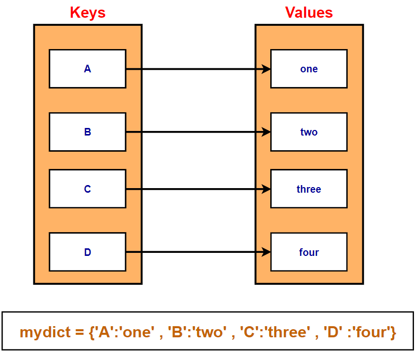

## Create Dictionary

```python
mydict = dict() # empty dictionary
mydict
```

```
{}
```

```python
mydict = {1:'one' , 2:'two' , 3:'three'} # dictionary with integer keys
mydict
```

```
{1: 'one', 2: 'two', 3: 'three'}
```

```python
mydict = dict({1:'one' , 2:'two' , 3:'three'}) # Create dictionary using dict()
mydict
```

```
{1: 'one', 2: 'two', 3: 'three'}
```

```python
mydict = {'A':'one' , 'B':'two' , 'C':'three'} # dictionary with character keys
mydict
```

```
{'A': 'one', 'B': 'two', 'C': 'three'}
```

```python
mydict = {1:'one' , 'A':'two' , 3:'three'} # dictionary with mixed keys
mydict
```

```
{1: 'one', 'A': 'two', 3: 'three'}
```

```python
mydict.keys() # Return Dictionary Keys using keys() method
```

```
dict_keys([1, 'A', 3])
```

```python
mydict.values() # Return Dictionary Values using values() method
```

```
dict_values(['one', 'two', 'three'])
```

```python
mydict.items() # Access each key-value pair within a dictionary
```

```
dict_items([(1, 'one'), ('A', 'two'), (3, 'three')])
```

```python
mydict = {1:'one' , 2:'two' , 'A':['asif' , 'john' , 'Maria']} # dictionary with mixed keys
mydict
```

```
{1: 'one', 2: 'two', 'A': ['asif', 'john', 'Maria']}
```

```python
mydict = {1:'one' , 2:'two' , 'A':['asif' , 'john' , 'Maria'],'B':('Bat' , 'cat' , 'hat')} # dictionary with mixed keys
mydict
```

```
{1: 'one',
 2: 'two',
 'A': ['asif', 'john', 'Maria'],
 'B': ('Bat', 'cat', 'hat')}
```

```python
mydict = {1:'one' , 2:'two' , 'A':{'Name':'asif' , 'Age' :20},'B':('Bat' , 'cat' , 'hat')} # dictionary with mixed keys
mydict
```

```
{1: 'one',
 2: 'two',
 'A': {'Name': 'asif', 'Age': 20},
 'B': ('Bat', 'cat', 'hat')}
```

```python
keys = {'a' , 'b' , 'c' , 'd'}
mydict3 = dict.fromkeys(keys)
mydict3
# Create a dictionary from a sequence of keys
```

```
{'b': None, 'a': None, 'c': None, 'd': None}
```

```python
keys = {'a' , 'b' , 'c' , 'd'}
value = 10
mydict3 = dict.fromkeys(keys , value)
mydict3
# Create a dictionary from a sequence of keys with value
```

```
{'b': 10, 'a': 10, 'c': 10, 'd': 10}
```

```python
keys = {'a' , 'b' , 'c' , 'd'}
value = [10,20,30]
mydict3 = dict.fromkeys(keys , value)
mydict3
# Create a dictionary from a sequence of keys with value list
```

```
{'b': [10, 20, 30], 'a': [10, 20, 30], 'c': [10, 20, 30], 'd': [10, 20, 30]}
```

```python
value.append(40)
mydict3
```

```
{'b': [10, 20, 30, 40],
 'a': [10, 20, 30, 40],
 'c': [10, 20, 30, 40],
 'd': [10, 20, 30, 40]}
```

## Accessing Items

```python
mydict = {1:'one' , 2:'two' , 3:'three' , 4:'four'}
mydict
```

```
{1: 'one', 2: 'two', 3: 'three', 4: 'four'}
```

```python
mydict[1] # Access item using key
```

```
'one'
```

```python
mydict.get(1) # Access item using get() method
```

```
'one'
```

```python
mydict1 = {'Name':'sonu' , 'ID': 4512 , 'DOB': 1997 , 'job' :'Data Science'}
mydict1
```

```
{'Name': 'sonu', 'ID': 4512, 'DOB': 1997, 'job': 'Data Science'}
```

```python
mydict1['Name']
# Access item using key
```

```
'sonu'
```

```python
mydict1.get('job')
# Access item using get() method
```

```
'Data Science'
```

## Add, Remove & Change Items

```python
mydict1 = {'Name':'Sonu' , 'ID': 4512 , 'DOB': 1997 , 'Address' : 'Gujarat'}
mydict1
```

```
{'Name': 'Sonu', 'ID': 4512, 'DOB': 1997, 'Address': 'Gujarat'}
```

```python
mydict1['DOB'] = 1992 # Changing Dictionary Items
mydict1['Address'] = 'Delhi'
mydict1
```

```
{'Name': 'Sonu', 'ID': 4512, 'DOB': 1992, 'Address': 'Delhi'}
```

```python
dict1 = {'DOB':1995}
mydict1.update(dict1)
mydict1
```

```
{'Name': 'Sonu', 'ID': 4512, 'DOB': 1995, 'Address': 'Delhi'}
```

```python
mydict1['Job'] = 'Analyst' # Adding items in the dictionary
mydict1
```

```
{'Name': 'Sonu', 'ID': 4512, 'DOB': 1995, 'Address': 'Delhi', 'Job': 'Analyst'}
```

```python
mydict1.pop('Job') # Removing items in the dictionary using Pop method
mydict1
```

```
{'Name': 'Sonu', 'ID': 4512, 'DOB': 1995, 'Address': 'Delhi'}
```

```python
mydict1.popitem() # A random item is removed
```

```
('Address', 'Delhi')
```

```python
mydict1
```

```
{'Name': 'Sonu', 'ID': 4512, 'DOB': 1995}
```

```python
del[mydict1['ID']] # Removing item using del method
mydict1
```

```
{'Name': 'Sonu', 'DOB': 1995}
```

```python
mydict1.clear() # Delete all items of the dictionary using clear method
mydict1
```

```
{}
```

```python
del mydict1 # Delete the dictionary object
mydict1
```

```
---------------------------------------------------------------------------
NameError                                 Traceback (most recent call last)
<ipython-input-125-da2fba4eca0f> in <module>
      1 del mydict1 # Delete the dictionary object
----> 2 mydict1

NameError: name 'mydict1' is not defined
```

## Copy Dictionary

```python
mydict = {'Name':'Sonu' , 'ID': 4515 , 'DOB': 1997 , 'Address' : 'Gujarat'}
mydict
```

```
{'Name': 'Sonu', 'ID': 4515, 'DOB': 1997, 'Address': 'Gujarat'}
```

```python
mydict1 = mydict # Create a new reference "mydict1"
```

```python
id(mydict) , id(mydict1) # The address of both mydict & mydict1 will be the same as both are pointing to same dictionary
```

```
(140523592853688, 140523592853688)
```

```python
mydict2 = mydict.copy() # Create a copy of the dictionary
```

```python
id(mydict2) # The address of mydict2 will be different from mydict because mydict2 is pointing to the copy of the existin
```

```
140523593090608
```

```python
mydict['Address'] = 'Mumbai'
```

```python
mydict
```

```
{'Name': 'Sonu', 'ID': 4515, 'DOB': 1997, 'Address': 'Mumbai'}
```

```python
mydict1 # mydict1 will be also impacted as it is pointing to the same dictionary
```

```
{'Name': 'Sonu', 'ID': 4515, 'DOB': 1997, 'Address': 'Mumbai'}
```

```python
mydict2 # Copy of list won't be impacted due to the changes made in the original dictionary
```

```
{'Name': 'Sonu', 'ID': 4515, 'DOB': 1997, 'Address': 'Gujarat'}
```

## Loop through a Dictionary

```python
mydict1 = {'Name':'Sonu' , 'ID': 4515 , 'DOB': 1997 , 'Address' : 'Gujarat' , 'Job': 'Data Science'}
mydict1
```

```
{'Name': 'Sonu',
 'ID': 4515,
 'DOB': 1997,
 'Address': 'Gujarat',
 'Job': 'Data Science'}
```

```python
for i in mydict1:
    print(i , ':' , mydict1[i]) # Key & value pair
```

```
Name : Sonu
ID : 4515
DOB : 1997
Address : Gujarat
Job : Data Science
```

```python
for i in mydict1:
    print(mydict1[i]) # Dictionary items
```

```
Sonu
4515
1997
Gujarat
Data Science
```

## Dictionary Membership

```python
mydict1 = {'Name':'Sonu' , 'ID': 4515 , 'DOB': 1997 , 'Job': 'Data Science'}
mydict1
```

```
{'Name': 'Sonu', 'ID': 4515, 'DOB': 1997, 'Job': 'Data Science'}
```

```python
'Name' in mydict1 # Test if a key is in a dictionary or not.
```

```
True
```

```python
'Sonu' in mydict1
# Membership test can be only done for keys.
```

```
False
```

```python
'ID' in mydict1
```

```
True
```

```python
'Address' in mydict1
```

```
False
```